# Introduction to R for Epidemiologists

Jenna Krall, PhD  
Thursday, January 15, 2015

### Introduction to R for Epidemiologists

Course details

- Thursdays 4:00 PM-5:50 PM
- Room: GCR 119
- Course website www.jennakrall.com/IntrotoRepi

Instructor and TA details

- Instructor: Dr. Jenna Krall, PhD
- E-mail: jenna.krall@emory.edu
- Office: GCR 369
- Office hours: 10 AM-11 AM Wednesdays and by appointment
- Lead TA: Brooke Alhanti
- TA: Anran Liu

### Introduction to R for Epidemiologists

Office hours with Anran

- Monday 12-1, 1-2, 2-3, 3-4, 4-5
- Tuesday 10-11, 11-12, 12-1, 3-4, 4-5
- Thursday 1-2, 2-3, 3-4

### Introduction to R for Epidemiologists

Prerequisites

- Introductory-level statistics course covering regression
- No programming experience required

What you need

- R and RStudio installed
- No required textbook

### Introduction to R for Epidemiologists

Class format

- 60 minute lecture
- 50 minute lab

These two portions of the class provide two different ways of learning R

1. I tell you how to do things
2. Self-guided learning (with help from us)

### Introduction to R for Epidemiologists

Grading

- 20% lab assignments
  - Must work on during class to receive credit
- 45% homework assignments (15% each)
  - May work with others
  - Must submit your own code
- 35% final project
  - Epidemiological analysis of real data
  - You may consult me or the TAs
  - You may not consult other students
- No late assignments will be accepted

### Introduction to R for Epidemiologists

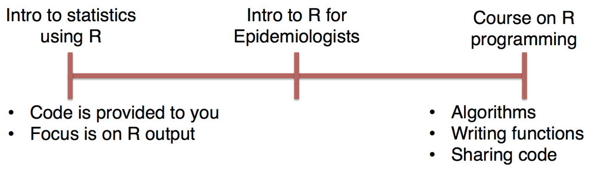

### Introduction to R for Epidemiologists

Course objectives

- Read in and clean data
- Compute summary statistics
- Apply and interpret statistical methods
- Create well-formatted output tables
- Create publication-quality figures
- Create reproducible reports

If there is time

- R packages
- Shiny applications

### Outline

1. History of R
2. R vs. other statistical programming languages
3. Orientation to R
4. Some basics
5. Getting data into R
6. Rules about programming
7. Resources

### History of R

- Programming language for statistical computing
- Derived from S language (John Chambers, Bell labs)
- GNU (Gnu's not UNIX) project: free and open source
- Developed by
  - Ross Ihaka (University of Auckland)
  - Robert Gentleman (Genentech)
- R can do almost anything
  - Users can create their own R packages
- R project: http://www.r-project.org/
- Comprehensive R Archive Network (CRAN): http://cran.r-project.org/

Ross Ihaka

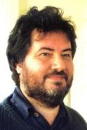

Robert Gentleman

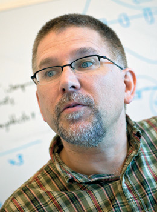

### R vs. other statistical programming languages

- The R language
  - We can create objects (e.g. a vector of heights)
  - Objects can interact with other objects (e.g. comparing height and age)
  - Programs consist of applying methods to objects (e.g. what is the mean height?)
- R is interactive
- R and RStudio
- R is easily customizable
  - Customize figures
  - Make nicely formatted tables
  - Write functions

### R vs. other statistical programming languages

SAS

- No interactivity
- Easy to look at your data
- Difficult to create customized output
- Can be more stable for complex models
- Need a lot of code to perform simple tasks (e.g. to find a mean)

In SAS,

```
 proc means data = data1;
 var variable1;
 run;
```

In R,

```
mean(variable1)
```

### R vs. other statistical programming languages

- STATA
  - One dataset at a time
  - Intuitive and easy data cleaning
- MATLAB
  - Matrix computation
  - Powerful
- SPSS
  - Intuitive
  - No programming required

### Orientation to R

The console

- Type code interactively
- Do not plan to save this code

Editor

- Save code for later
- Can run in console from editor

### Orientation to R

R vs. RStudio

- R opens the console
- RStudio
  - Runs usual R
  - Nice layout with different panels for editor, console, etc.
  - Additional features
  - *Can customize the arrangement of the windows*

### Orientation to R

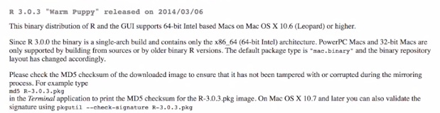

### Orientation to R

[figure not shown]

### The basics

```r
5 + 3
```

```
[1] 8
```

```r
123/2 + (2 * 17.2)
```

```
[1] 95.9
```

### The basics

Can store results using assignment operators

As an example:

```r
nameofobject <- 5
print(nameofobject)
```

```
[1] 5
```

```r
nameofobject2 = 5
print(nameofobject2)
```

```
[1] 5
```

Generally `<-` is preferred

### The basics

Can calculate result as object:

```r
nameofsum <- 5 + 3
print(nameofsum)
```

```
[1] 8
```

```r
nameofsum
```

```
[1] 8
```

Objects can be functions of other objects:

```r
nameofnew <- nameofobject + nameofsum
nameofnew
```

```
[1] 13
```

### The basics

Objects can be reassigned

- Recall that we created an R object `nameofobject`

```r
nameofobject
```

```
[1] 5
```

- Suppose we reassign the name

```r
nameofobject <- 1500
nameofobject
```

```
[1] 1500
```

### Classes

- So far, all the R objects we have dealt with have been numeric (number valued).
- There are different data classes that R objects can belong to
- The `class` function in R can tell us the class of an R object

```r
class(nameofobject)
```

```
[1] "numeric"
```

- String or character objects that are non-numeric

```r
nameofstring <- "IntrotoR"
nameofstring
```

```
[1] "IntrotoR"
```

```r
class(nameofstring)
```

```
[1] "character"
```

### Classes

We can also create vectors by combining numbers or text. The `c` function in R combines objects together.

```r
vector1 <- c(6, 2, 3, 4)
vector1
```

```
[1] 6 2 3 4
```

```r
class(vector1)
```

```
[1] "numeric"
```

```r
length(vector1)
```

```
[1] 4
```

### Classes

Vectors can also consist of strings

```r
vectorstring <- c("R", "is", "awesome", "for", "Epidemiologists")
vectorstring
```

```
[1] "R"               "is"              "awesome"         "for"
[5] "Epidemiologists"
```

```r
class(vectorstring)
```

```
[1] "character"
```

```r
length(vectorstring)
```

```
[1] 5
```

### Classes

Mixing data classes

```r
vectormix <- c("Intro", "to", "R", "version", 1)
vectormix
```

```
[1] "Intro"   "to"      "R"       "version" "1"
```

```r
class(vectormix)
```

```
[1] "character"
```

```r
length(vectormix)
```

```
[1] 5
```

### Classes

Factors in R

```r
grades <- c("A", "B", "A", "A", "C", "F", "D", "B")
grades
```

```
[1] "A" "B" "A" "A" "C" "F" "D" "B"
```

```r
class(grades)
```

```
[1] "character"
```

```r
factorgrades <- factor(grades)
factorgrades
```

```
[1] A B A A C F D B
Levels: A B C D F
```

```r
class(factorgrades)
```

```
[1] "factor"
```

### Classes

Why does class matter?

- Functions will perform differently for different classes
  - Print function for factor shows levels
  - Mean of a character vector is meaningless
- There are many other classes
  - Next class: matrices, data frames, lists, dates
  - Classes for output (e.g. linear model class lm)
  - In R, you can create your own classes of R objects

### Selecting elements

Use brackets to select elements of a vector

```r
vectorstring
```

```
[1] "R"               "is"              "awesome"         "for"
[5] "Epidemiologists"
```

```r
vectorstring[1]
```

```
[1] "R"
```

```r
vectorstring[5]
```

```
[1] "Epidemiologists"
```

### R functions

- Used as nameoffunction(Robject)

```r
vector1
```

```
[1] 6 2 3 4
```

```r
mean(vector1)
```

```
[1] 3.75
```

- Functions can take several arguments separated by commas

```r
mean(vector1, trim = 0.25)
```

```
[1] 3.5
```

```r
log(1)
```

```
[1] 0
```

### R functions

```r
length(vector1)
```

```
[1] 4
```

```r
median(vector1)
```

```
[1] 3.5
```

```r
summary(vector1)
```

```
   Min. 1st Qu.  Median    Mean 3rd Qu.    Max.
   2.00    2.75    3.50    3.75    4.50    6.00
```

```r
ls()
```

```
 [1] "factorgrades"  "grades"        "nameofnew"     "nameofobject"
 [5] "nameofobject2" "nameofstring"  "nameofsum"     "vector1"
 [9] "vectormix"     "vectorstring"
```

### Packages

Packages include tools to perform many different analyses

- Some packages are preloaded
  - base (`mean`, `print`, `length`), stats (`median`, `lm`)
  - datasets
  - graphics
- Can install and load additional packages from CRAN
  - ggplot2, RColorBrewer (advanced graphics)
  - dplyr, reshape2 (data cleaning/manipulation tools)

Installing a package (may need to specify a CRAN mirror)

```
install.packages("ggplot2")
```

Loading a package

```
library(ggplot2)
```

### Working directory

Where R

- looks for data
- saves data, figures, etc.

```r
getwd()
```

```
[1] "/Users/jennakrall/Dropbox/IntrotoREpi/data"
```

Change your working directory using `setwd`

```r
setwd("/Users/jennakrall/Dropbox/")
```

### Working directory

- For Windows users, setwd(“C:/Users/yourusername/etc.”)
- For Mac users, setwd(“/Users/yourusername/etc.”)
- Can use home directory

```r
setwd("~/")
getwd()
```

```
[1] "/Users/jennakrall"
```

### Getting data into R

R can read in data from many different sources

Types of data files

- R data files: (extension .RData or .rda)
- CSV file: comma separated values (extension .csv).
- Excel file: Microsoft Office (extension .xls or .xlsx). Can use excel to create a .csv file or read into R directly.
- SAS: datafiles (extension .sas7bdat) or Xport file (extension .xpt)

**You must either specify the path to the data or set your working directory to the where the data are located**

### Getting data into R

Example using .RData or .rda files

```r
load("googleflu.RData")
ls()
```

```
[1] "flu"
```

```r
head(flu)
```

```
        Date United.States Georgia Atlanta HHSRegion4
1 2003-09-28           902     514     519        631
2 2003-10-05           952     532     484        652
3 2003-10-12          1092     557     497        735
4 2003-10-19          1209     608     563        822
5 2003-10-26          1249     745     845        797
6 2003-11-02          1374     767     771        850
```

```r
class(flu)
```

```
[1] "data.frame"
```

### Getting data into R

Example using .csv file

```r
flu <- read.csv("googleflu.csv", stringsAsFactors = FALSE)
head(flu)
```

```
        Date United.States Georgia Atlanta HHSRegion4
1 2003-09-28           902     514     519        631
2 2003-10-05           952     532     484        652
3 2003-10-12          1092     557     497        735
4 2003-10-19          1209     608     563        822
5 2003-10-26          1249     745     845        797
6 2003-11-02          1374     767     771        850
```

```r
class(flu)
```

```
[1] "data.frame"
```

### Getting data into R

Example using .xls or .xlsx file

```r
library(XLConnect)
wkbook_flu <- loadWorkbook("googleflu.xlsx")
class(wkbook_flu)
```

```
[1] "workbook"
attr(,"package")
[1] "XLConnect"
```

```r
flu <- readWorksheet(wkbook_flu, 1)
```

### Getting data into R

Example using .xls or .xlsx file

```r
head(flu)
```

```
        Date United.States Georgia Atlanta HHSRegion4
1 2003-09-28           902     514     519        631
2 2003-10-05           952     532     484        652
3 2003-10-12          1092     557     497        735
4 2003-10-19          1209     608     563        822
5 2003-10-26          1249     745     845        797
6 2003-11-02          1374     767     771        850
```

```r
class(flu)
```

```
[1] "data.frame"
```

### Getting data into R

Example using SAS

1. Save SAS data as .csv and read into R
2. Use SAS Xport Transport file
3. Read SAS data directly
   - Only if SAS is installed
   - Do not recommend

### Getting data into R

1) Save SAS data as .csv and read into R

- Save data (.sas7bdat) in SAS as .csv file

```
proc export data = googleflu
    outfile = "googleflu.csv"
    dbms = csv replace;
putnames = yes;
run;
```

- Then use `read.csv` function in R

```r
flu <- read.csv("googleflu.csv", stringsAsFactors = FALSE)
```

### Getting data into R

2) Use SAS Xport Transport file

SAS xport files

- Save data in SAS as SAS xport file

```
* Set xport filepath ;
libname lib1 xport "H:\googleflu.xpt";

* Set the xport file ;
data lib1.flu;
* This is your original data;
set flu;
run;
```

### Getting data into R

2) Use SAS Xport Transport file

- Read xport file into R

```r
library(Hmisc)
flu <- sasxport.get("googleflu.xpt")
```

```
Processing SAS dataset FLU   ..
```

```r
head(flu)
```

```
        date   us georgia atlanta hhs
1 2003-09-28  902     514     519 631
2 2003-10-05  952     532     484 652
3 2003-10-12 1092     557     497 735
4 2003-10-19 1209     608     563 822
5 2003-10-26 1249     745     845 797
6 2003-11-02 1374     767     771 850
```

### Getting data into R

3) Read SAS data directly (only if SAS is installed)

- This command sometimes yields ambiguous errors from SAS
- Need Windows/SAS
- Use `read.ssd` function to read `.sas7bdat` file directly into R
  - `read.ssd` function in R creates xport file (using SAS)
  - reads the resulting dataset into R using `read.xport`.

```r
library(foreign)
lib1 <- "c:/"
flu <- read.ssd(lib1, "flu", sascmd = "filepath/to/where/SAS/is")
```

*May need to tell R where to find SAS using sascmd argument.*

### Getting data into R

Other functions to read in data include

- read.table
- read.delim
- readLines
- scan
- many others

### Rules about programming

- Always comment your code– your grade will depend on it (and so will your future self)

```r
# This is the mean of our numeric vector
mean(vector1)
```

```
[1] 3.75
```

> Your closest collaborator is you six months ago but you don’t reply to email. – Erin Jonaitis (via Andrew Gelman)
- Use appropriate spacing

```r
newvector <- c(5, 3, 4, 4)
```

### Rules about programming

- Lines of code should be truncated before 80 characters

```r
newvector <- c(28, 90, 10, 57, 66, 93, 29, 95, 19, 14, 96, 78, 61, 51, 1, 87,
    60, 46, 43, 35, 17, 64, 2, 55, 54, 25, 92, 32, 42, 94, 97, 86, 77, 6, 13,
    23, 20, 67, 30, 68, 12, 5, 24, 59, 33, 75, 26, 65, 88, 31, 47, 38, 53, 70,
    27, 98, 16, 8, 37, 15, 11, 40, 85, 83, 76, 91, 81, 48, 80, 7, 36, 22, 89,
    39, 4, 63, 21, 79, 99, 45, 56, 100, 44, 18, 3, 58, 73, 52, 62, 72, 69, 71,
    74, 84, 82, 49, 34, 50, 9, 41)
```

### Rules about programming

Naming conventions

- The more descriptive, the better
- Names are case sensitive
- Capitalization and camelCase can make objects hard to type and remember
- Can use underscores to separate words in names

```r
new_vector <- c(1, 2, 3, 4)
new_vector
```

```
[1] 1 2 3 4
```

- Don't overwrite existing R functions or objects (e.g. `c` or `T`)

Style guides:

- Hadley Wickham: http://r-pkgs.had.co.nz/style.html
- Google's: https://google-styleguide.googlecode.com/svn/trunk/Rguide.xml

### Resources

- R help files (use `?function`)

```
?mean
help.search("mean")
```

- Search engines
  - Google: Append CRAN onto your google search for R.
  - R seek: http://www.rseek.org/
- Stack Overflow: http://stackoverflow.com/questions/tagged/r
- UCLA R stats: http://www.ats.ucla.edu/stat/r/
- Other resources: www.jennakrall.com/IntrotoRepi/resources.html